# Praca domowa 2

## Dane

Dane wykorzystane w Pracy domowej 2 są związane z kampaniami marketingu bezpośredniego portugalskiej instytucji bankowej. Kampanie marketingowe opierały się na rozmowach telefonicznych. Często wymagany był więcej niż jeden kontakt z tym samym klientem, aby uzyskać dostęp do tego, czy produkt (lokata bankowa) zostanie (lub nie) subskrybowany. Opis wszystkich kolumn znajduje się również w pliku `README.md`.

#### Dane klienta banku

| Zmienna | Opis |
| --- | --- |
| **age** | wiek |
| **job** : admin., unknown, unemployed, management, housemaid, entrepreneur, student, blue-collar, self-employed, retired, technician, services | administrator, nieznany, bezrobotny, kierownictwo, pokojówka, przedsiębiorca, student, pracownik fizyczny, samozatrudniony, emeryt, technik, usługi |
| **marital** : married, divorced, single; note: divorced means divorced or widowed) | żonaty/zamężna, rozwiedzion_, kawaler/panna; uwaga: rozwiedzion_ oznacza rozwiedzion_ lub owdowiał_ |
| **education** : unknown, secondary, primary, tertiary | nieznane, średnie, podstawowe, wyższe |
| **default** : yes, no | czy kredyt jest niespłacany : tak, nie |
| **balance** : average yearly balance, in euros | średnie roczne saldo w euro |
| **housing** : has housing loan? yes, no | czy posiada kredyt mieszkaniowy? tak, nie |
| **loan** : has personal loan? yes, no | ma pożyczkę osobistą? tak, nie |

#### Dane związane z ostatnim kontaktem w bieżącej kampanii

| Zmienna | Opis |
| --- | --- |
| **contact** : unknown, telephone, cellular | nieznany, telefon, komórkowy |
| **day** : last contact day of the month | dzień miesiąca ostatniego kontaktu |
| **month** : last contact month of year, jan, feb, mar, …, nov, dec | miesiąc ostatniego kontaktu w roku, styczeń, luty, marzec, …, listopad, grudzień |
| **duration** : last contact duration, in seconds | czas trwania ostatniego kontaktu w sekundach |

## Zadanie 1

Weźmy pod uwagę zawody (`job`) klientów banku. Który zawód zacząco wyróżnia się w posiadaniu kredytu mieszkaniowego lub pożyczki osobistej?

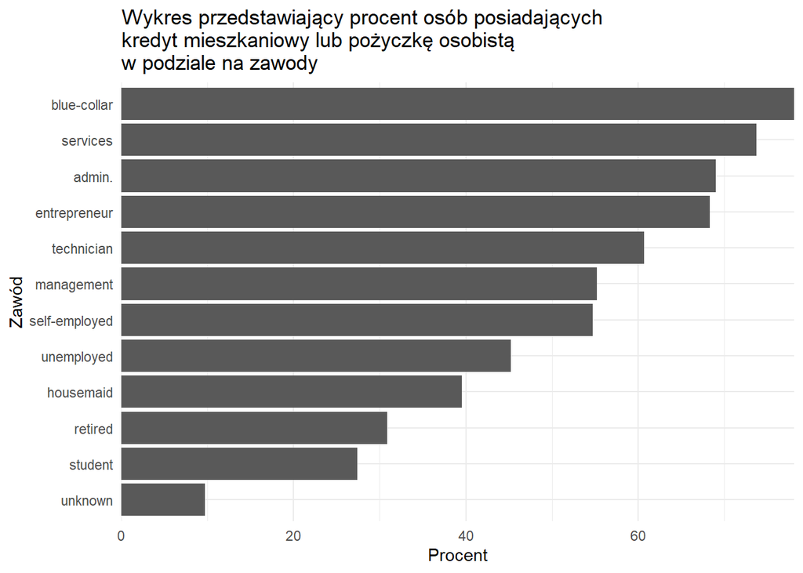

```r
# Tu umieść kod do wygenerowania odpowiedzi do zadania.
 df %>% group_by(job) %>%
  summarise(any_loan_pct =
              mean(housing == "yes" | loan == "yes") * 100) %>%
  ggplot(aes(any_loan_pct, reorder(job, any_loan_pct))) + geom_col() +
  theme_minimal() +
  labs(title = "Wykres przedstawiający procent osób posiadających \nkredyt mieszkaniowy lub pożyczkę osobistą \nw podziale na zawody",
       x = "Procent",
       y = "Zawód") +
  scale_x_continuous(expand = c(0,0))
```

**Komentarz: Najbardziej wyróżniającym się zawodem w posiadaniu kredytu lub pożyczki jest “blue-collar”. Oprócz tego wysoki procent takich osob jest wśród zawodów: services, admin., enterprenuer**

## Zadanie 2

Wybierając klientów, którzy mają nieznany sposób kontaktu (`contact`). Jak rozkłada się ich wiek w podziale na status związku?

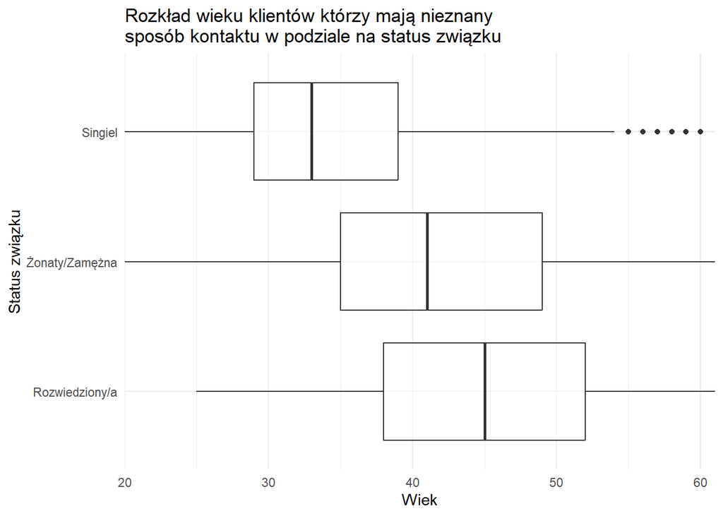

```r
# Tu umieść kod do wygenerowania odpowiedzi do zadania.
df %>% filter(contact == "unknown") %>%
  ggplot(aes(x = age, y = marital)) +
  geom_boxplot(alpha = 1/2) +
  theme_minimal() +
  labs( title = "Rozkład wieku klientów którzy mają nieznany \nsposób kontaktu w podziale na status związku",
        x = "Wiek",
        y = "Status związku") +
  scale_y_discrete(labels = c(
    "single" = "Singiel",
    "married" = "Żonaty/Zamężna",
    "divorced" = "Rozwiedziony/a")) +
  scale_x_continuous(expand = c(0,0))
```

**Komentarz: Najwięcej singlów mających nieznany sposób kontaktu ma między 29a 39 lat, mediana ich wieku jest to 33 lata. Dla osób żonatych/zamężnych jest to przedział 35 - 49 lat a mediana to 41 lat. Dla osoób rozwiedzionych to 38 - 52 lata i mediana to 45 lat.**

## Zadanie 3

Jaka jest różnica pomiędzy średnim rocznym saldem w euro w zależności od wykształcenia i tego czy kredyt jest niespłacany?

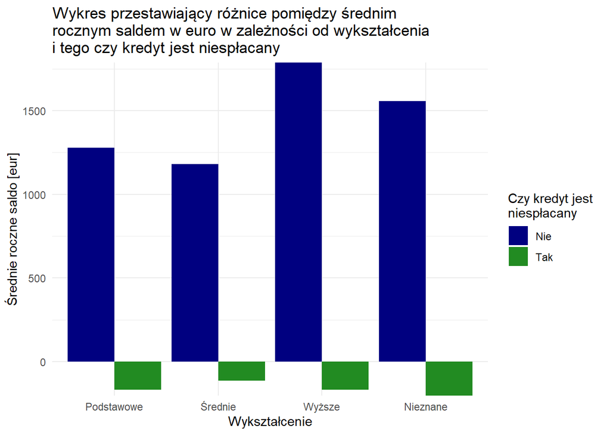

```r
# Tu umieść kod do wygenerowania odpowiedzi do zadania.
df %>% group_by(education, default) %>%
  summarise(mean_balance = mean(balance, rm.na = TRUE)) %>%
  ggplot(aes(education, mean_balance, fill = default)) +
  geom_col(position = "dodge") +
  scale_y_continuous(expand = c(0,0)) +
  labs(title = "Wykres przestawiający różnice pomiędzy średnim \nrocznym saldem w euro w zależności od wykształcenia \ni tego czy kredyt jest niespłacany",
       x = "Wykształcenie",
       y = "Średnie roczne saldo [eur]",
       fill = "Czy kredyt jest \nniespłacany") +
  scale_x_discrete(labels = c("primary" = "Podstawowe", "secondary" = "Średnie", "tertiary" = "Wyższe", "unknown" = "Nieznane")) + theme_minimal() +
  scale_fill_manual(values = c("navy", "forestgreen"), labels = c("Nie","Tak"))
```

**Komentarz: Średnie roczne saldo jest najwyższe wśród osób o wyższym wykształceniu i mających spłacany kredyt. Wśród osób mających niespłacany kredyt dominuje grupa osób o nieznanym wykształceniu**

## Zadanie 4

Czy dzień i miesiąc kontaktu z klientem ma wpływ na średni czas trwania rozmowy w stosunku do średniego czasu trwania rozmowy?

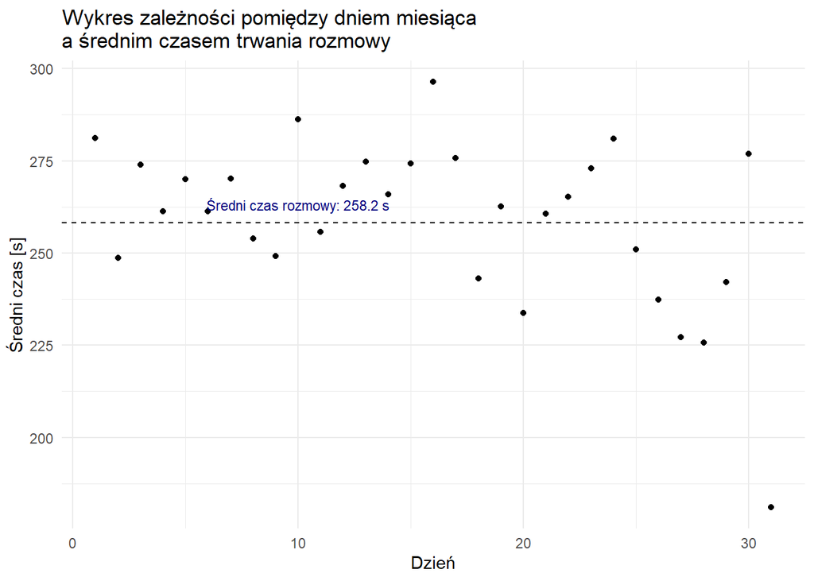

```r
# Tu umieść kod do wygenerowania odpowiedzi do zadania.
global_mean_duration <- mean(df$duration, na.rm = TRUE)
month_order <- c("jan", "feb", "mar", "apr", "may", "jun",
                 "jul", "aug", "sep", "oct", "nov", "dec")


df %>% group_by(day) %>%
  summarise(mean_duration = mean(duration, na.rm = TRUE)) %>%
  ggplot(aes(day, mean_duration)) +
  geom_point() +
  geom_hline(yintercept = global_mean_duration, linetype = "dashed", color = "black")  +
  labs(title = "Wykres zależności pomiędzy dniem miesiąca \na średnim czasem trwania rozmowy",
       x = "Dzień",
       y = "Średni czas [s]") +
  annotate("text", x = 10, y = global_mean_duration + 5,
           label = paste("Średni czas rozmowy:", round(global_mean_duration, 1), "s"),
           color = "navyblue", size = 3) +
  theme_minimal()
```

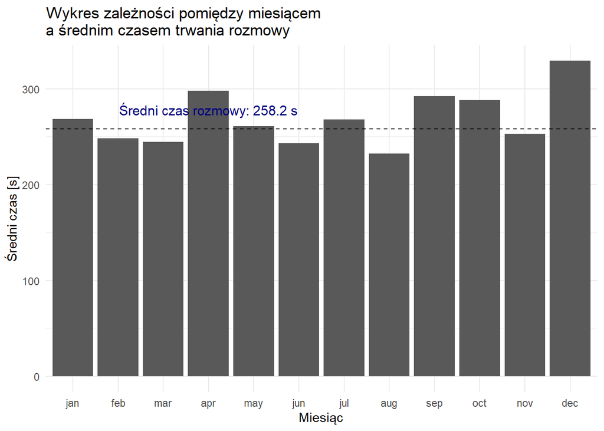

```r
df %>% group_by(month) %>% mutate(month = factor(month, levels = month_order)) %>%
  summarise(mean_duration = mean(duration, na.rm = TRUE)) %>%
  ggplot(aes(month, mean_duration)) +
  geom_col(position = "identity") +
  geom_hline(yintercept = global_mean_duration, linetype = "dashed", color = "black") +
  labs(title = "Wykres zależności pomiędzy miesiącem \na średnim czasem trwania rozmowy",
       x = "Miesiąc",
       y = "Średni czas [s]") +
  annotate("text", x = "apr", y = global_mean_duration + 20,
           label = paste("Średni czas rozmowy:", round(global_mean_duration, 1), "s"),
           color = "navyblue", size = 4) +
  theme_minimal()
```

**Komentarz: Nie ma wyraźnej zależności między dniem i miesiącem a średnim czasem trwania rozwowy w stosunku do średniego czasu trwania rozmowy.**

## Zadanie 5

Czy jest zależnośc pomiędzy wiekiem klientów a ich średnim rocznym saldzie w euro w podziale na stopień wykształcenia?

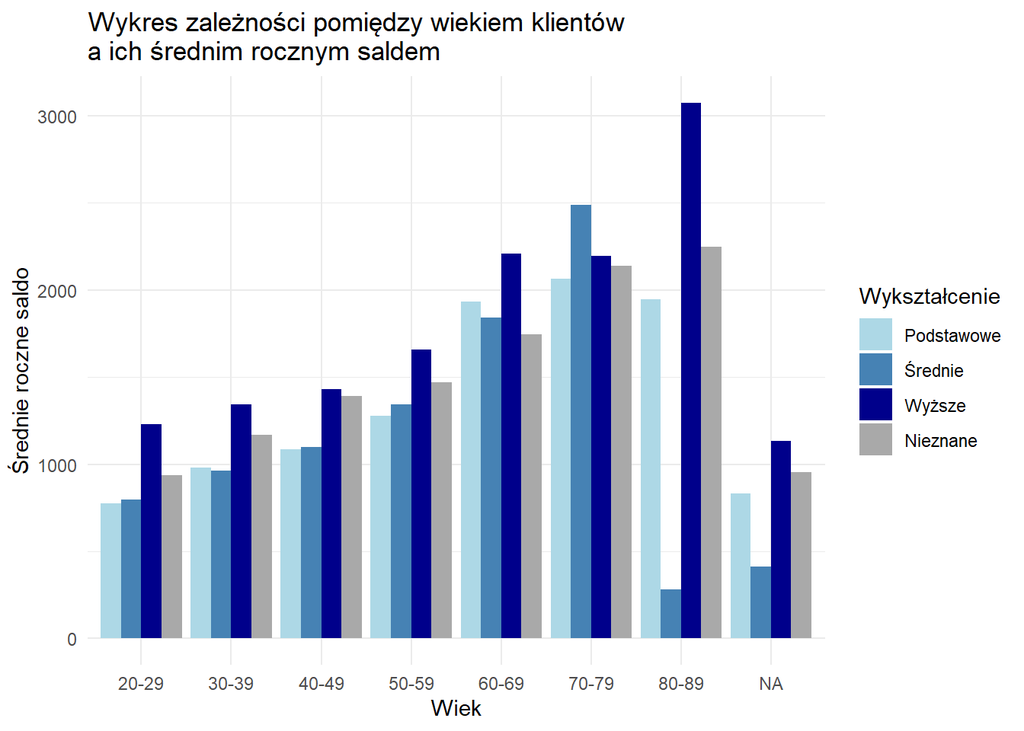

```r
# Tu umieść kod do wygenerowania odpowiedzi do zadania.
df %>%
  filter(between(balance, quantile(balance, 0.01, na.rm = TRUE),
                          quantile(balance, 0.99, na.rm = TRUE))) %>%
  mutate(age_breaks =
           cut(age, breaks = c(20, 30, 40, 50, 60, 70, 80, 90),
      labels = c("20-29", "30-39", "40-49", "50-59", "60-69", "70-79", "80-89"))) %>%
  group_by(age_breaks, education) %>%
  mutate(mean_balance = mean(balance, na.rm = TRUE)) %>%
  ggplot(aes(age_breaks, mean_balance, fill = education)) +
  geom_col(position = "dodge") +
  labs(title = "Wykres zależności pomiędzy wiekiem klientów \na ich średnim rocznym saldem",
       x = "Wiek",
       y = "Średnie roczne saldo",
       fill = "Wykształcenie") +
  scale_fill_manual(values = c("primary" = "lightblue", "secondary" = "steelblue", "tertiary" = "darkblue", "unknown" = "darkgrey"),
                    labels = c("primary" = "Podstawowe", "secondary" = "Średnie", "tertiary" = "Wyższe", "unknown" = "Nieznane")) + theme_minimal()
```

## Zadanie 6

Rozważmy osoby, które są bezrobotne albo ich zawód jest nieznany. Czy procent osób, które są bezrobotne i nie spłacają kredytu jest większy od procenta osób o nieznanym zawodzie i nie spłacanym kredycie? Jaki typ kredytu jest (przez te osoby) najczęściej niespłacany?

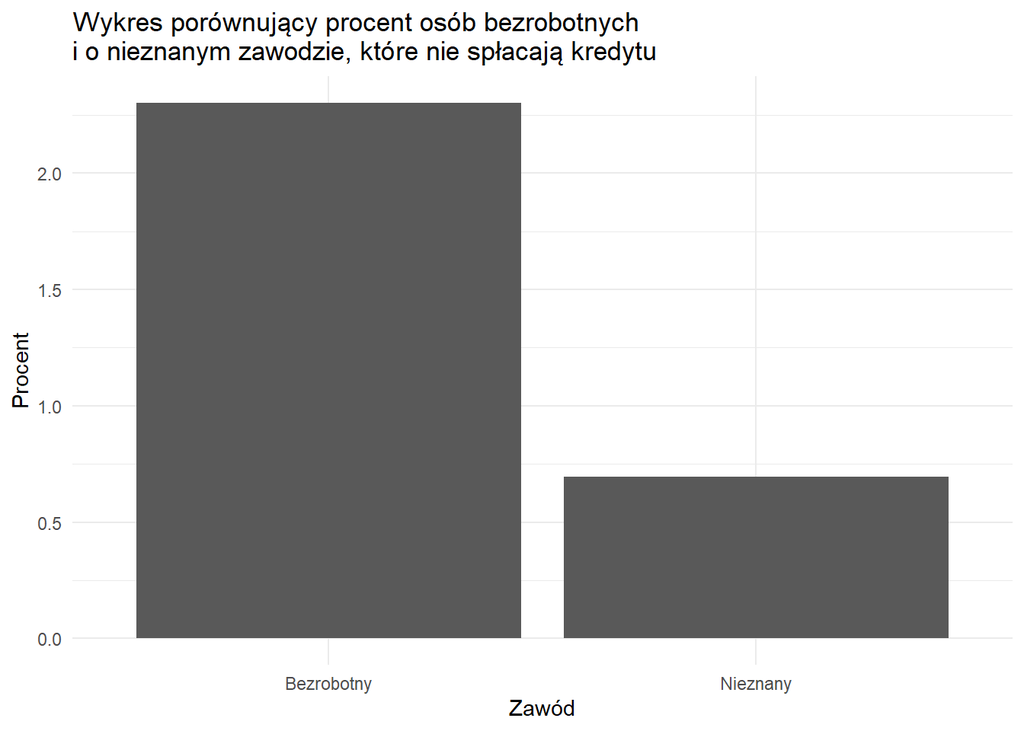

```r
# Tu umieść kod do wygenerowania odpowiedzi do zadania.
df %>%  filter(job %in% c("unknown", "unemployed")) %>%
  group_by(job) %>%
  summarise(count = n(),
            not_paying = sum(default == "yes"),
            percent = not_paying/count*100
         ) %>%
  ggplot(aes(job, percent)) + geom_col() +
  labs(title = "Wykres porównujący procent osób bezrobotnych \ni o nieznanym zawodzie, które nie spłacają kredytu",
       x = "Zawód",
       y = "Procent") +
  scale_x_discrete(labels = c("unemployed" = "Bezrobotny", "unknown" = "Nieznany")) + theme_minimal()
```

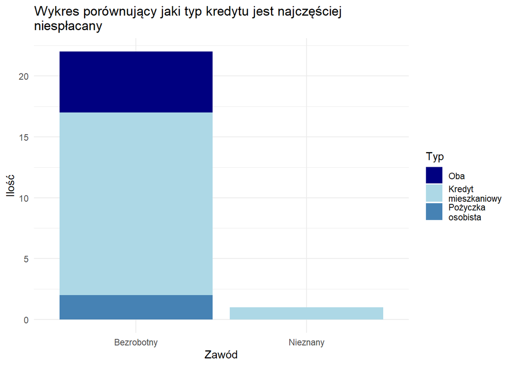

```r
df %>%
  filter(job %in% c("unknown", "unemployed"), default == "yes") %>%
  mutate(type = ifelse(housing == "yes", ifelse(loan =="yes", "both", "housing"), ifelse(loan == "yes", "loan", "none"))) %>%
  group_by(job, type) %>%
  summarise(count = n()) %>%
  filter(type != "none") %>%
  ggplot(aes(job, count, fill = type)) + geom_col() +
  labs(title = "Wykres porównujący jaki typ kredytu jest najczęściej \nniespłacany",
       x = "Zawód",
       y = "Ilość",
       fill = "Typ") +
  scale_x_discrete(labels = c("unemployed" = "Bezrobotny", "unknown" = "Nieznany")) + theme_minimal() +
  scale_fill_manual(values = c("navyblue", "lightblue", "steelblue"), labels = c("Oba","Kredyt \nmieszkaniowy", "Pożyczka \nosobista"))
```

**Komentarz: Tak, procent osob bezrobotnych o niespłacanym kredycie jest większy niż osób, których zawód jest nieznany i niespłacają kredytu. Ponadto najczęsniej niespłacanym typem kresytu jest kredyt mieszkaniowy dla obu rozważanych grup.**